# Presupuesto Económico ingresos 2021

## Instalar las librerías con las que vamos a estar trabajando

Pandas es una biblioteca y libreria de python que sirve para el análisis de datos

```python
!pip install pandas
```

# Configuración de pandas

importamos la libreria Panda y la renombramos como "pd" para utilizarlo en el resto del notebook y del trabajo que vamos a realizar

```python
import pandas as pd
```

# Creación de variables

creamos las variables que contienen los datos que vamos a usar mediante [`=`]

```python
url_presupuesto = "https://datos.alcobendas.org/dataset/0be2930e-5aab-4790-9e81-2c5cdb6a995a/resource/fbadb8f2-5f7c-4425-b72b-356f53a48512/download/presupuesto-economico-ingresos-2021.-normalizado.csv"
```

Ahora vamos a comprobar si la variable se ha creado correctamente

```python
url_presupuesto
```

```
'https://datos.alcobendas.org/dataset/0be2930e-5aab-4790-9e81-2c5cdb6a995a/resource/fbadb8f2-5f7c-4425-b72b-356f53a48512/download/presupuesto-economico-ingresos-2021.-normalizado.csv'
```

# Creación de un nuevo DataFrame

Creamos un DataFrame de Pandas leyendo el csv de la base de datos. Un DataFrame en python es una estructura de datos con dos dimensiones en la cual se puede guardar datos de distintos tipos (como caractéres, enteros, valores de punto flotante, factores y más) en columnas, según la página web de [Trabaja con Pandas](https://datacarpentry.org/python-ecology-lesson-es/02-starting-with-data/#:~:text=Un%20DataFrame%20es%20una%20estructura,de%20SQL%20o%20el%20data.)

```python
df = pd.read_csv(url_presupuesto)
```

A continuación vamos a mostrar el nuevo DataFrame creado

```python
df
```

|  | Código | Nombre | Crédito inicial del ejercicio |
| --- | --- | --- | --- |
| 0 | NaN | Clasificación económica de ingresos | 1.427355e+08 |
| 1 | 1.0 | IMPUESTOS DIRECTOS | 7.992915e+07 |
| 2 | 10.0 | Impuesto sobre la Renta | 7.704034e+06 |
| 3 | 100.0 | Impuestos sobre la Renta de las Personas Físicas | 7.704034e+06 |
| 4 | 101.0 | Impuesto sobre Sociedades | 0.000000e+00 |
| ... | ... | ... | ... |
| 325 | 930.0 | Préstamos recibidos en moneda distinta del eur... | 0.000000e+00 |
| 326 | 931.0 | Préstamos recibidos en moneda distinta del eur... | 0.000000e+00 |
| 327 | 94.0 | Depósitos y fianzas recibidos | 0.000000e+00 |
| 328 | 940.0 | Depósitos recibidos | 0.000000e+00 |
| 329 | 941.0 | Fianzas recibidas | 0.000000e+00 |

330 rows × 3 columns

# Exploración del Dataframe

## Información general

Mediante [`df.info()`] es como se puede mostrar la información de la tabla

En la información sobre el Dataframe de la tabla elegida se observa como incluye el indice (que es RangeIndex), además del número de tablas, el número de columnas que hay (Data columns) el nombre de las mismas (colum), la cantidad de los datos nulos que posee la tabla (esto se ve el non-null), el tipo de variable de las columnas (con dtype) y el tamaño (memory usage).

```python
df.info()
```

```
<class 'pandas.core.frame.DataFrame'>
RangeIndex: 330 entries, 0 to 329
Data columns (total 3 columns):
 #   Column                         Non-Null Count  Dtype
---  ------                         --------------  -----
 0   Código                         329 non-null    float64
 1   Nombre                         330 non-null    object
 2   Crédito inicial del ejercicio  330 non-null    float64
dtypes: float64(2), object(1)
memory usage: 7.9+ KB
```

## Cabecera

Mediante [`df.head()`] se muestran las primeras entradas de la tabla y entre paréntesis se puede indicar cuantas entradas se quieren mostrar

```python
df.head()
```

|  | Código | Nombre | Crédito inicial del ejercicio |
| --- | --- | --- | --- |
| 0 | NaN | Clasificación económica de ingresos | 1.427355e+08 |
| 1 | 1.0 | IMPUESTOS DIRECTOS | 7.992915e+07 |
| 2 | 10.0 | Impuesto sobre la Renta | 7.704034e+06 |
| 3 | 100.0 | Impuestos sobre la Renta de las Personas Físicas | 7.704034e+06 |
| 4 | 101.0 | Impuesto sobre Sociedades | 0.000000e+00 |

## Cola

Ahora hay que mostrar las últimas entradas de la tabla (tail) mediante [`df.tail()`]

De nuevo, entre paréntesis se puede especificar el numero de entradas que se quiere mostrar

```python
df.tail()
```

|  | Código | Nombre | Crédito inicial del ejercicio |
| --- | --- | --- | --- |
| 325 | 930.0 | Préstamos recibidos en moneda distinta del eur... | 0.0 |
| 326 | 931.0 | Préstamos recibidos en moneda distinta del eur... | 0.0 |
| 327 | 94.0 | Depósitos y fianzas recibidos | 0.0 |
| 328 | 940.0 | Depósitos recibidos | 0.0 |
| 329 | 941.0 | Fianzas recibidas | 0.0 |

## Columnas

Se puede mostrar el nombre de las columnas mediante [`df.columns`]

```python
df.columns
```

```
Index(['Código', 'Nombre', 'Crédito inicial del ejercicio'], dtype='object')
```

También se pueden mostrar columnas en concreto mediante `df['nombre de la columna']`

A continuación se ejemplifica con una de las columnas "Crédito inicial del ejercicio"

```python
df['Crédito inicial del ejercicio']
```

```
0      1.427355e+08
1      7.992915e+07
2      7.704034e+06
3      7.704034e+06
4      0.000000e+00
           ...
325    0.000000e+00
326    0.000000e+00
327    0.000000e+00
328    0.000000e+00
329    0.000000e+00
Name: Crédito inicial del ejercicio, Length: 330, dtype: float64
```

También se puede mostrar un número de fila cualquiera

```python
df['Crédito inicial del ejercicio'][2]
```

```
7704033.82
```

## Ahora se muestran las variables estadísticas

Mediante [`df.describe()`] se muestran las variables estadísticas del dataframe, algo que no se muestra normalmente

```python
df.describe()
```

|  | Código | Crédito inicial del ejercicio |
| --- | --- | --- |
| count | 329.000000 | 3.300000e+02 |
| mean | 403.929514 | 1.814044e+06 |
| std | 275.541759 | 1.024341e+07 |
| min | 1.000000 | 0.000000e+00 |
| 25% | 115.000000 | 0.000000e+00 |
| 50% | 394.000000 | 0.000000e+00 |
| 75% | 600.000000 | 8.100000e+01 |
| max | 941.000000 | 1.427355e+08 |

## Indexar el Dataframe según una columna

También es posible indexar u ordenar los datos en función de una columna mediante [`df.set_index('')`]

En este caso se indexa u ordena el dataframe según la columna "Nombre"

```python
df.set_index('Nombre')
```

| Nombre | Código | Crédito inicial del ejercicio |
| --- | --- | --- |
| Clasificación económica de ingresos | NaN | 1.427355e+08 |
| IMPUESTOS DIRECTOS | 1.0 | 7.992915e+07 |
| Impuesto sobre la Renta | 10.0 | 7.704034e+06 |
| Impuestos sobre la Renta de las Personas Físicas | 100.0 | 7.704034e+06 |
| Impuesto sobre Sociedades | 101.0 | 0.000000e+00 |
| ... | ... | ... |
| Préstamos recibidos en moneda distinta del euro a corto plazo | 930.0 | 0.000000e+00 |
| Préstamos recibidos en moneda distinta del euro a largo plazo | 931.0 | 0.000000e+00 |
| Depósitos y fianzas recibidos | 94.0 | 0.000000e+00 |
| Depósitos recibidos | 940.0 | 0.000000e+00 |
| Fianzas recibidas | 941.0 | 0.000000e+00 |

330 rows × 2 columns

```python
df.set_index('Nombre')['Crédito inicial del ejercicio']
```

```
Nombre
Clasificación económica de ingresos                              1.427355e+08
IMPUESTOS DIRECTOS                                               7.992915e+07
Impuesto sobre la Renta                                          7.704034e+06
Impuestos sobre la Renta de las Personas Físicas                 7.704034e+06
Impuesto sobre Sociedades                                        0.000000e+00
                                                                     ...
Préstamos recibidos en moneda distinta del euro a corto plazo    0.000000e+00
Préstamos recibidos en moneda distinta del euro a largo plazo    0.000000e+00
Depósitos y fianzas recibidos                                    0.000000e+00
Depósitos recibidos                                              0.000000e+00
Fianzas recibidas                                                0.000000e+00
Name: Crédito inicial del ejercicio, Length: 330, dtype: float64
```

## Creación del gráfico a partir de la varibale "Nombre" y de la otra variable "Crédito inicial del ejercicio"

Una vez indexados los datos segun la variable de "nombre" y también la variable de "crédito inicial del ejercicio" mediante [`.plot`] se muestran los datos en un gráfico

Ahora si añadimos [`title=`] como el argumento de .plot se le pone el nombre al gráfico

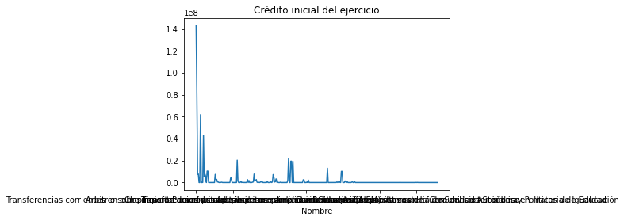

```python
df.set_index('Nombre')['Crédito inicial del ejercicio'].plot(title="Crédito inicial del ejercicio")
```

## Ahora vamos a realizar otro gráfico a partir de la elección de otras variables

Vamos a elegir "Nombre" y "Código" y se van a indexar estos datos

```python
df.set_index('Nombre')['Código']
```

```
Nombre
Clasificación económica de ingresos                                NaN
IMPUESTOS DIRECTOS                                                 1.0
Impuesto sobre la Renta                                           10.0
Impuestos sobre la Renta de las Personas Físicas                 100.0
Impuesto sobre Sociedades                                        101.0
                                                                 ...
Préstamos recibidos en moneda distinta del euro a corto plazo    930.0
Préstamos recibidos en moneda distinta del euro a largo plazo    931.0
Depósitos y fianzas recibidos                                     94.0
Depósitos recibidos                                              940.0
Fianzas recibidas                                                941.0
Name: Código, Length: 330, dtype: float64
```

## A continuación vamos a hacer el gráfico mediante estos datos

Una vez indexados los datos nuevos des la variable de "nombre" y también la variable de "código" mediante [.plot] se muestran los datos en un gráfico

Y ahora, al igual que se ha hecho antes vamos a mostrar el gráfico con los nuevos datos

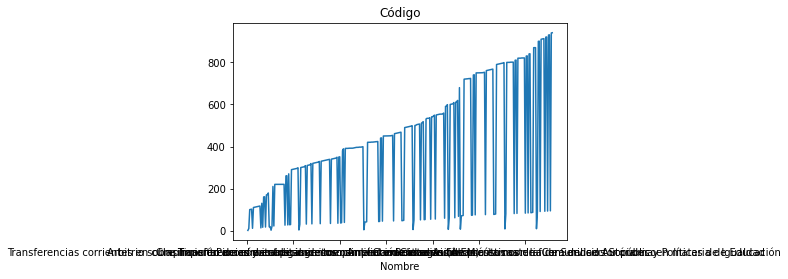

```python
df.set_index('Nombre')['Código'].plot(title="Código")
```

## Comparación entre los datos de Código y el Crédito incial del ejercicio

Ahora lo que se va a hacer es comparar ambos datos en base al nombre

Para poder realizar esto es necesario definir dos nuevas variables

```python
codigo = df.set_index('Nombre')['Código']
credito_incial = df.set_index('Nombre')['Crédito inicial del ejercicio']
```

Antes de creae el Dataframe y el correspondiente gráfico hay que concatenarlos mediante [vs]

```python
vs = pd.concat([codigo,credito_incial],axis=1)
vs
```

| Nombre | Código | Crédito inicial del ejercicio |
| --- | --- | --- |
| Clasificación económica de ingresos | NaN | 1.427355e+08 |
| IMPUESTOS DIRECTOS | 1.0 | 7.992915e+07 |
| Impuesto sobre la Renta | 10.0 | 7.704034e+06 |
| Impuestos sobre la Renta de las Personas Físicas | 100.0 | 7.704034e+06 |
| Impuesto sobre Sociedades | 101.0 | 0.000000e+00 |
| ... | ... | ... |
| Préstamos recibidos en moneda distinta del euro a corto plazo | 930.0 | 0.000000e+00 |
| Préstamos recibidos en moneda distinta del euro a largo plazo | 931.0 | 0.000000e+00 |
| Depósitos y fianzas recibidos | 94.0 | 0.000000e+00 |
| Depósitos recibidos | 940.0 | 0.000000e+00 |
| Fianzas recibidas | 941.0 | 0.000000e+00 |

330 rows × 2 columns

## Creación de un gráfico de comparación

Ahora que ya estan los datos concatenados vamos a realizar la comparación mediante la creación de un gráfico

[figure not shown]

```python
vs.columns =['Crédito inicial del ejercicio', 'Código']
vs.plot(title="codigo vs credito_inicial")
```

## Guardamos en un CSV

Ahora es cuando todo lo que hemos hecho hay que guardarlo en el archivo csv

```python
vs.to_csv('presupuesto.csv')
```

Ahora tenemos que comprobar si el archivo se ha creado con [`ls`] y al ser esta opción un comando de bash se pone [`!`] para asi poder usarlo

```python
!ls
```

```
API-pandas-folium.ipynb		 probando-con-r.ipynb
escit.png			 python-csv-encuesta-pandas.ipynb
esvit.csv			 Shared_Resources
phyton-api-covid19-pandas.ipynb  Untitled1.ipynb
presupuesto.csv			 Untitled.ipynb
```

Importamos ahora matplotlib.pyplot y lo nombramos como plt

[figure not shown]

```python
import matplotlib.pyplot as plt
vs.plot()
plt.savefig('presupuesto.png')
```